# E4-1-1-1

## 解析 "Plot"

`Figure`是這個層次結構中的頂級容器。這是整個視窗/頁面，所有內容都是繪製的。你可以擁有多個獨立的數位，而`` Figure`可以包含多個 ``Axes``。

大多數人都在“軸”上策劃。軸實際上是我們繪製資料的區域以及與之相關的任何刻度/標籤/等。通常我們會設置一個Axes，調用`subplot`（將Axes置於常規網格上），因此在大多數情況下，`Axes`和`Subplot`是同義詞。

每個`Axes`都有一個`XAxis`和一個`YAxis`。這些包含刻度，刻度位置，標籤等。在本教程中，我們主要通過其他機制控制刻度，刻度標籤和資料限制，因此我們不會觸及所有內容的“軸”部分。那麼多。但是，這裡值得一提的是解釋術語“軸”的來源。

這些物件的關係可以用下面的圖來表示：

示例圖像：

具體結構：

```python
import numpy as np
import matplotlib.pyplot as plt

# Try to reproduce the figure shown in images/exercise_1-1.png

# Our data...
x = np.linspace(0, 10, 100)
y1, y2, y3 = np.cos(x), np.cos(x + 1), np.cos(x + 2)
names = ['Signal 1', 'Signal 2', 'Signal 3']

# Can you figure out what to do next to plot x vs y1, y2, and y3 on one figure?
```

```python
import numpy as np
import matplotlib.pyplot as plt
```

## 運用figure 物件創建圖形

`figure` 物件是最外層的繪圖單位，預設是以 `1` 開始編號（**MATLAB** 風格，`Figure 1, Figure 2, ...`），可以用 `plt.figure()` 產生一幅圖像，除了預設參數外，可以指定的參數有：

- `num` - 編號
- `figsize` - 圖像大小
- `dpi` - 解析度
- `facecolor` - 背景色
- `edgecolor` - 邊界顏色
- `frameon` - 邊框

這些屬性也可以通過 `Figure` 物件的 `set_xxx` 方法來改變。

```python
fig = plt.figure(facecolor=(1, 0, 0, .1))   # red background to see where the figure is
```

結果什麼都沒發生！ 這是因為預設情況下，mpl在被告知之前不會顯示任何內容，我們需要呼叫`plt.show（）`才能顯示圖形

```python
plt.show()
```

[output not shown]

通過`figsize`參數可以控制圖形的大小，這個參數需要一個以英寸為單位的`` `（寬度，高度） ``元組。

```python
# Twice as tall as it is wide:
fig = plt.figure(figsize=plt.figaspect(2.0), facecolor=(1, 0, 0, .1))
plt.show()
```

[output not shown]

### subplot

`subplot` 主要是使用網格排列子圖：

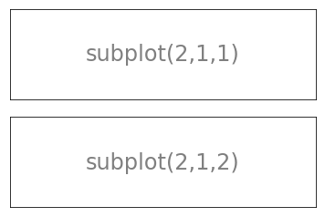

```python
%pylab inline

subplot(2,1,1)
xticks([]), yticks([])
text(0.5,0.5, 'subplot(2,1,1)',ha='center',va='center',size=24,alpha=.5)

subplot(2,1,2)
xticks([]), yticks([])
text(0.5,0.5, 'subplot(2,1,2)',ha='center',va='center',size=24,alpha=.5)

show()
```

更高級的可以用 `gridspec` 來繪圖：

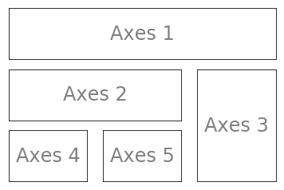

```python
import matplotlib.gridspec as gridspec

G = gridspec.GridSpec(3, 3)

axes_1 = subplot(G[0, :])
xticks([]), yticks([])
text(0.5,0.5, 'Axes 1',ha='center',va='center',size=24,alpha=.5)

axes_2 = subplot(G[1,:-1])
xticks([]), yticks([])
text(0.5,0.5, 'Axes 2',ha='center',va='center',size=24,alpha=.5)

axes_3 = subplot(G[1:, -1])
xticks([]), yticks([])
text(0.5,0.5, 'Axes 3',ha='center',va='center',size=24,alpha=.5)

axes_4 = subplot(G[-1,0])
xticks([]), yticks([])
text(0.5,0.5, 'Axes 4',ha='center',va='center',size=24,alpha=.5)

axes_5 = subplot(G[-1,-2])
xticks([]), yticks([])
text(0.5,0.5, 'Axes 5',ha='center',va='center',size=24,alpha=.5)

show()
```